# MCA

Szymon Talaga

14.12.2014

Raport przedstawia wyniki Wielokrotnej Analizy Korespondencji (MCA) na zbiorach porządkowych i nominalnych zmiennych dotyczących aktywności i preferencji kulturalnych oraz statusu socjoekonomicznego. W celu otrzymania w pełni poprawnego rozwiązania zastosowano korektę wartości własnych wymiarów rozwiązana (Greenacre, 2006). Dodatkowo, obok pozycji kategorii odpowiedzi w przestrzeni rozwiązania obliczono również współrzędne respondentów. Posłużono się do tego tzw. wzorem przejścia (Rouanet, 2006; Greenacre, 2006).

Wczytanie niezbędnych pakietów i funckji oraz zbioru danych:

```r
library(lattice)
library(psych)
library(ca)
library(knitr)
source("../DataReduction/MCAhelper.R")
source("../HelperFunctionsMisc/ComputingMisc.R")
load("../MainData/MainData7.RData")
D.back = D
```

## MCA dla zmiennych związanych z aktywnością i preferencjami kulturalnymi

Przygotowanie danych:

```r
vars = names(D.back)[c(9:11, 21:30, 35:37)]
D = D.back[, vars]
```

MCA:

```r
cc.mca = mjca(D, nd=NA, lambda="adjusted")
summary(cc.mca)
```

```
##
## Principal inertias (eigenvalues):
##
##  dim    value      %   cum%   scree plot
##  1      0.026499  57.5  57.5  *************************
##  2      0.004740  10.3  67.7  ****
##  3      0.002353   5.1  72.8  **
##  4      0.001336   2.9  75.7  *
##  5      0.000924   2.0  77.7  *
##  6      0.000262   0.6  78.3
##  7      0.000186   0.4  78.7
##  8      0.000164   0.4  79.1
##  9      6.8e-050   0.1  79.2
##  10     4e-05000   0.1  79.3
##  11     00000000   0.0  79.3
```

[output cut: 95 more lines]

Jak widać dwa pierwsze wymiary zachowują aż 67,7% wariancji, co jest zdecydowanie dobrym wynikiem. Co więcej praktycznie wszystkie zmienne i kategorie odpowiedzi (poza dosłownia kilkoma przypadkami) charakteryzują się wysoką lub bardzo wysoką jakością reprodukcji na dwuwymiarowej płaszczyźnie rozwiązania (wartość qlt). Co więcej dosyć równomiernie rozłożone wartości udziału punktów w wymiarach (wartość ctr) pokazują, że rozwiązanie nie jest patologicznie zdominowane przez tylko jedną bądź kilka kategorii odpowiedzi.

Inspekcja wartości korelacji pokazuje, że właściwie we wszystkich przypadkach dominuje pierwszy wymiar. Wymiar drugi jest wyraźnie resztowy. Dodatkowo interpretacja będzie wsparta graficznym przedstawieniem rozwiązania.

Graficzna prezentacja dla dwóch pierwszych wymiarów:

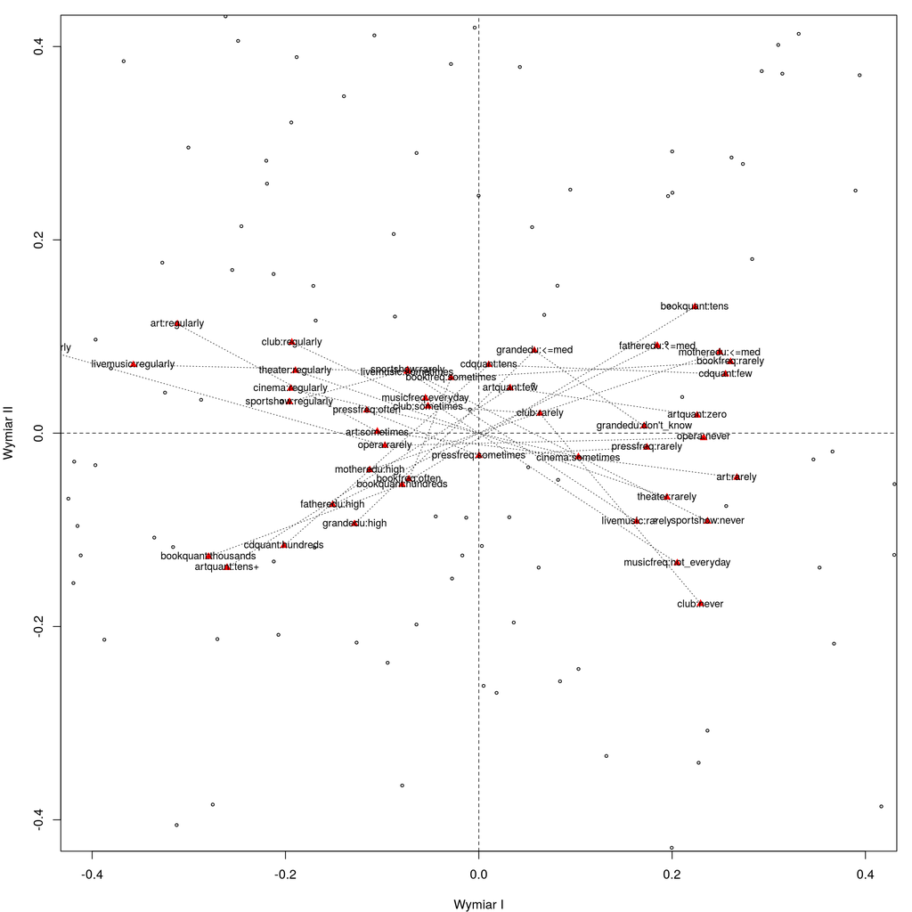

Jak widać pierwszy wymiar zdecydowanie można interpretować jako klasycznie rozumiany ogólny kapitał kulturowy, który łączy zarówno stopień uczestnictwa w kulturze oraz poziom jej rozumienia jak i zmaterializowany kapitał kulturowy. Interpretacja drugiego wymiaru jest trudniejsza i tak naprawdę ma mały sens. Ewidentnie jest to wymiar resztowy (i wszystkie pozostałe też), co oznacza, że zasadnicza informacja zawarta w analizowanym zbiorze zmiennych jest jednowymiarowa. Wszystkie pozostałe wymiary, wydaje się, są raczej niczym więcej jak tylko dopasowywaniem danych do przypadkowego szumu. W związku z tym tylko pierwszy wymiar zostanie wyekstrachowany do dalszych analiz. Należy również zwrócić uwagę, że kierunek wymiaru jest odwrócony, tj. współrzędne ujemne odpowiadają wysokiemu kapitałowi kulturowemu.

Obliczenie współrzędnych respondentów (funkcja własna ‘projectInd’ zawarta w: “MCAhelper.R”):

```r
cc.ind.coord = projectInd(D, cc.mca)
D.back$cultcap = cc.ind.coord[,1] * (-1) # wyniki są odwrócone, żeby nowo zapisania zmienna odpowidała kapitałowi kulturowemu a nie jego przeciwieństwu
```

Trafność teoretyczna zostanie sprawdzona przez sprawdzenie korelacji kapitału kulturowego z miarami preferencji kulturalnych:

```
##             tvinf tvlwb tvhgh tvpop tvcns mvspc mvshg mvslg bkshg bkslw
## tvinfo       1.00
## tvlowbrow    0.12  1.00
## tvhighbrow   0.13  0.18  1.00
## tvpop        0.42  0.39  0.13  1.00
## tvcons       0.09  0.22  0.21 -0.03  1.00
## moviesepic  -0.05  0.03  0.38  0.07  0.14  1.00
## movieshigh   0.40  0.22  0.16  0.36  0.13  0.12  1.00
## movieslight  0.10  0.00  0.20 -0.14  0.34  0.08  0.11  1.00
## bookshigh   -0.22  0.06  0.24  0.02  0.11  0.60 -0.01  0.00  1.00
## bookslow     0.33  0.14  0.24  0.24  0.12  0.14  0.47  0.08  0.08  1.00
## booksknow   -0.09  0.24  0.30 -0.04  0.13  0.21  0.01  0.12  0.11  0.03
## booksfant   -0.10 -0.03  0.05 -0.16  0.23  0.08 -0.04  0.62  0.05  0.03
## pressgen     0.28  0.42  0.26  0.39  0.11  0.32  0.24  0.00  0.31  0.33
## pressknow   -0.28 -0.05  0.17 -0.13  0.02  0.27 -0.25  0.09  0.24 -0.20
## presscons    0.16  0.23  0.04  0.06  0.43  0.07  0.17  0.09  0.01  0.29
## presslib     0.15  0.24  0.09  0.45 -0.17  0.21  0.12 -0.15  0.23  0.16
## pressspec    0.14  0.05  0.02  0.29  0.13  0.20  0.10 -0.05  0.08  0.21
## musichigh   -0.26  0.03  0.24 -0.15  0.09  0.47 -0.07  0.08  0.51  0.05
## musicmodern  0.19  0.01 -0.07 -0.09  0.18 -0.04  0.05  0.17 -0.08  0.01
## musicrock   -0.11 -0.04  0.00 -0.21  0.15  0.16 -0.05  0.27  0.00  0.00
## musicafro    0.11  0.18  0.01  0.14  0.16 -0.10  0.25 -0.07 -0.14  0.13
## cultcap     -0.11  0.03  0.08 -0.03  0.06  0.35  0.00  0.10  0.46  0.07
##             bkskn bksfn prssg prssk prssc prssl prsss mschg mscmd mscrc
## booksknow    1.00
## booksfant    0.02  1.00
## pressgen     0.24 -0.16  1.00
## pressknow    0.24  0.10  0.06  1.00
## presscons    0.00  0.05  0.27 -0.08  1.00
## presslib     0.07 -0.22  0.50  0.01  0.10  1.00
## pressspec    0.13  0.02  0.22  0.28  0.20  0.30  1.00
## musichigh    0.27  0.06  0.24  0.34 -0.02  0.16  0.14  1.00
## musicmodern  0.03  0.01  0.08 -0.17 -0.04 -0.04 -0.01  0.05  1.00
## musicrock    0.10  0.41 -0.10  0.09 -0.04 -0.13 -0.03  0.12 -0.02  1.00
## musicafro    0.07 -0.15  0.15 -0.16  0.18  0.03  0.03  0.02  0.07 -0.03
## cultcap      0.13  0.03  0.21  0.19 -0.15  0.21  0.03  0.43  0.17  0.05
##           mscfr cltcp
## musicafro  1.00
## cultcap   -0.04  1.00
```

Stosunkowo wysokie korelacje ($r \geq$ 0,40) z bookshigh i musichigh zdają się potwierdzać teoretyczną trafnośc obliczonej skali. Dla większej czytelności poniżej przedstawiono macierz korelacji tylko z tymi dwiema zmiennymi:

```
##           bkshg mschg cltcp
## bookshigh 1.00
## musichigh 0.51  1.00
## cultcap   0.46  0.43  1.00
```

Zauważmy, że rozkład kapitału kulturowego jest względnie symetryczny, co jest dobrym znakiem:

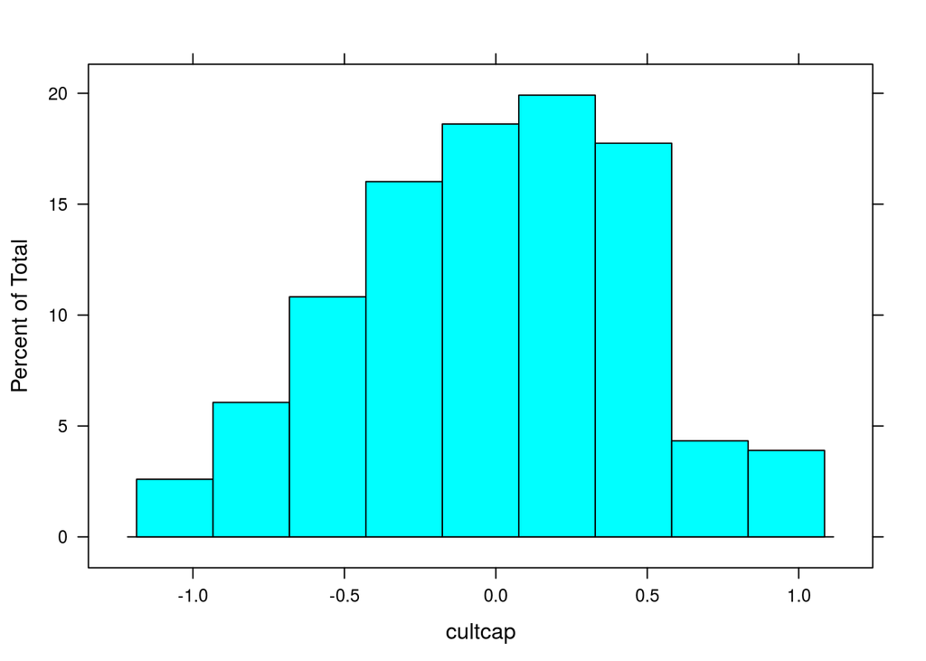

Jako że kapitał kulturowy tworzy tylko jeden wymiar, to możliwe jest liniowe uporządkowanie poszczególnych kategorii odpowiedzi pod względem ich znaczenia dla kapitału kulturowego:

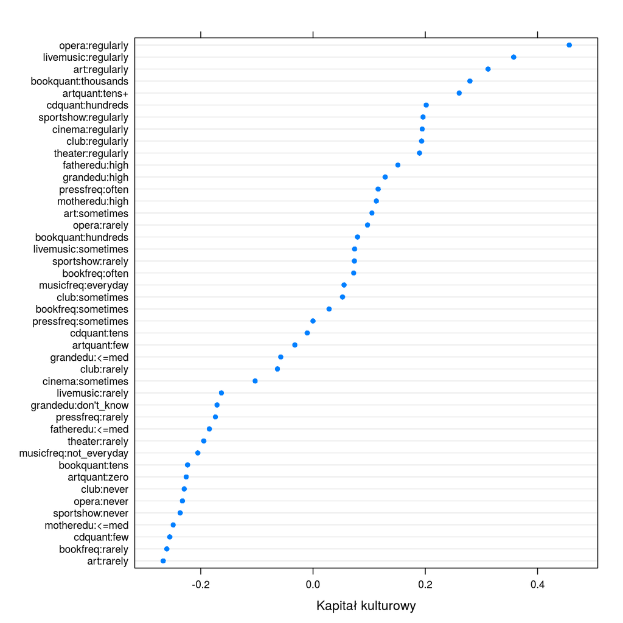

## MCA dla zmiennych związanych ze statusem socjoekonomicznym i demografią

Przygotowanie zmiennych:

```r
D = D.back
vars = names(D.back)[c(2,6:8,14:18,39:40)]
D = D.back[, vars]
```

MCA:

```r
sed.mca = mjca(D, nd=NA, lambda="adjusted")
summary(sed.mca)
```

```
##
## Principal inertias (eigenvalues):
##
##  dim    value      %   cum%   scree plot
##  1      0.031527  53.8  53.8  *************************
##  2      0.008930  15.2  69.1  *******
##  3      0.001611   2.8  71.8  *
##  4      0.000808   1.4  73.2
##  5      0.000530   0.9  74.1
##  6      0.000258   0.4  74.6
##         -------- -----
##  Total: 0.058572
##
##
## Columns:
```

[output cut: 58 more lines]

Dodatkowy wgląd w sens otrzymanego rozwiązania dostarcza jego graficzna prezentacja:

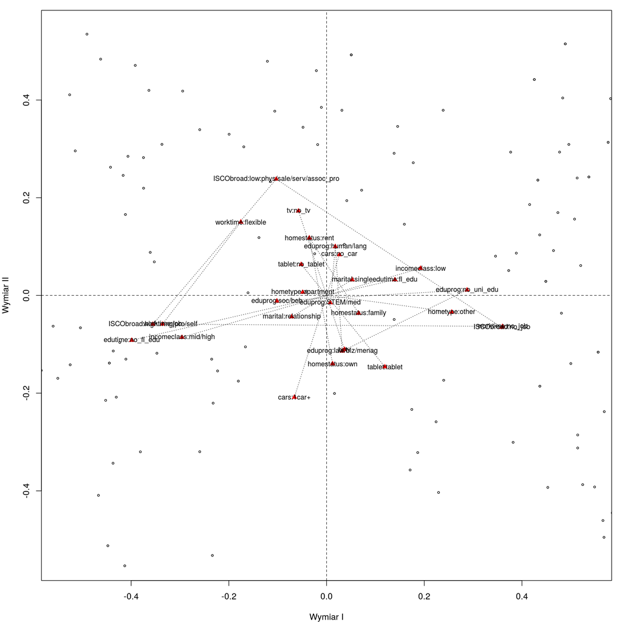

Należy zwrócić uwagę, że i w tym przypadku wymiary są odwrócone - wysokie dodatnie współrzędne odpowiadają niskiej stabilizacji i małemu posiadaniu.

Zapisanie współrzednych respondentów:

```r
sed.ind.coord = projectInd(D, sed.mca)
D.back$lifestab = sed.ind.coord[,1] * (-1)
D.back$wealth = sed.ind.coord[,2] * (-1)
```

Brak wyraźnych korelacji z preferencjami kulturowymi i kapitałem kulturowym wskazuje na satysfakcjonującą trafność teoretyczną obu skal:

```
##               civic resmb sccnt attgn attgv attds attnt tvinf tvlwb tvhgh
## civic          1.00
## resmob         0.02  1.00
## soccont        0.10  0.43  1.00
## attgen         0.11  0.26  0.25  1.00
## attgiven       0.03  0.02  0.11  0.57  1.00
## attdiscovered  0.16  0.29  0.29  0.61  0.30  1.00
## attnoatt      -0.05  0.02 -0.02 -0.39 -0.57 -0.09  1.00
## tvinfo        -0.08  0.05 -0.12  0.00  0.08 -0.09 -0.03  1.00
## tvlowbrow      0.01  0.03 -0.11  0.06  0.08  0.14 -0.07  0.12  1.00
## tvhighbrow     0.08  0.07 -0.02  0.09 -0.08  0.11  0.00  0.13  0.18  1.00
## tvpop          0.01  0.13 -0.01  0.09  0.04  0.09  0.01  0.42  0.39  0.13
## tvcons         0.22 -0.05 -0.11 -0.07  0.10 -0.01 -0.04  0.09  0.22  0.21
## moviesepic     0.16  0.01  0.09  0.01 -0.09  0.09 -0.07 -0.05  0.03  0.38
## movieshigh     0.02  0.09 -0.01 -0.10  0.01  0.01  0.01  0.40  0.22  0.16
## movieslight    0.19 -0.07 -0.02 -0.08 -0.02 -0.10  0.03  0.10  0.00  0.20
## bookshigh      0.17  0.18  0.11  0.07 -0.04  0.25 -0.10 -0.22  0.06  0.24
## bookslow      -0.06  0.14 -0.05  0.02  0.06  0.04 -0.06  0.33  0.14  0.24
## booksknow      0.15 -0.03  0.16  0.09 -0.12  0.17 -0.04 -0.09  0.24  0.30
## booksfant      0.11 -0.08 -0.12 -0.08 -0.07 -0.12  0.07 -0.10 -0.03  0.05
## pressgen       0.08  0.17  0.00  0.13  0.05  0.19 -0.13  0.28  0.42  0.26
## pressknow      0.07 -0.01  0.18  0.06 -0.11  0.06  0.12 -0.28 -0.05  0.17
## presscons     -0.01 -0.01 -0.16 -0.09  0.15 -0.07 -0.14  0.16  0.23  0.04
## presslib       0.05  0.12  0.05  0.17  0.08  0.18 -0.10  0.15  0.24  0.09
## pressspec      0.03  0.08  0.15  0.02  0.03  0.03  0.13  0.14  0.05  0.02
## musichigh      0.20  0.10  0.20  0.01 -0.05  0.24  0.03 -0.26  0.03  0.24
## musicmodern    0.05  0.03  0.07  0.10  0.09  0.10 -0.04  0.19  0.01 -0.07
## musicrock      0.11 -0.18 -0.06  0.00  0.03 -0.05 -0.04 -0.11 -0.04  0.00
## musicafro      0.03  0.04  0.02 -0.07  0.07 -0.06  0.00  0.11  0.18  0.01
## cultcap        0.31  0.27  0.41  0.22  0.06  0.34 -0.03 -0.11  0.03  0.08
## lifestab       0.15  0.31  0.32  0.16  0.06  0.23  0.05 -0.06  0.04 -0.05
## wealth        -0.04  0.03  0.11  0.13  0.09  0.07  0.02  0.15  0.02 -0.05
##             tvpop tvcns mvspc mvshg mvslg bkshg bkslw bkskn bksfn prssg
## tvpop        1.00
## tvcons      -0.03  1.00
## moviesepic   0.07  0.14  1.00
## movieshigh   0.36  0.13  0.12  1.00
## movieslight -0.14  0.34  0.08  0.11  1.00
## bookshigh    0.02  0.11  0.60 -0.01  0.00  1.00
## bookslow     0.24  0.12  0.14  0.47  0.08  0.08  1.00
```

[output cut: 12 more lines]

```
## lifestab     0.01  0.03 -0.04 -0.05 -0.01  0.00 -0.08  0.14 -0.07  0.03
## wealth       0.12 -0.12 -0.07  0.02 -0.08 -0.11  0.06 -0.03 -0.07  0.03
##             prssk prssc prssl prsss mschg mscmd mscrc mscfr cltcp lfstb
## pressknow    1.00
## presscons   -0.08  1.00
## presslib     0.01  0.10  1.00
## pressspec    0.28  0.20  0.30  1.00
## musichigh    0.34 -0.02  0.16  0.14  1.00
## musicmodern -0.17 -0.04 -0.04 -0.01  0.05  1.00
## musicrock    0.09 -0.04 -0.13 -0.03  0.12 -0.02  1.00
## musicafro   -0.16  0.18  0.03  0.03  0.02  0.07 -0.03  1.00
## cultcap      0.19 -0.15  0.21  0.03  0.43  0.17  0.05 -0.04  1.00
## lifestab     0.14 -0.11  0.02  0.03  0.05  0.02  0.01  0.01  0.16  1.00
## wealth      -0.12 -0.06 -0.04  0.00 -0.17  0.07 -0.07  0.00  0.12  0.00
## [1]  1.00
```

Rozkłady skal:

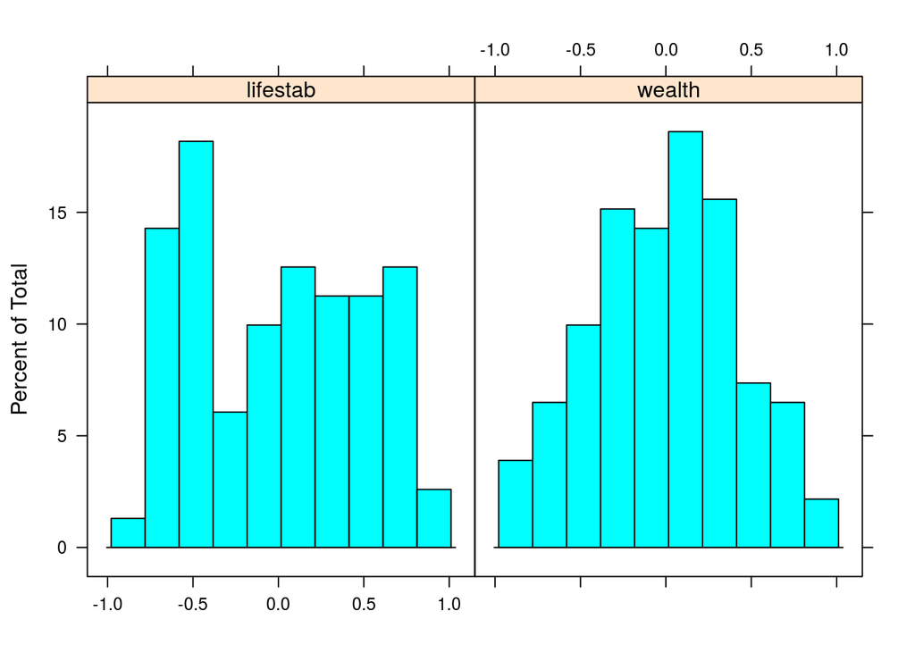